USTHB

Faculté de Mathématiques

M2 MIND/ ANADISS

2022/2023

Réaliser par l’étudiante: AISSANI Anouar

# 1. l’objectif du TP

L’objectif de ce travail est de prédire la nature d’eaux de vie {KIRSCH, MIRAB, POIRE} à partir de leur 8 compositions: “TYPE”, “MEOH”, “ACET”, “BU1”, “BU2”, “ISOP”, “MEPR”, “PRO1”, “ACAL”.

Pour réaliser ce travail il faut passer par les deux étapes principals:

- La première est de distinguer, parmi les variables observées de la table “eaux de vie”, celles qui prennent des valeurs différentes suivant les trois classes {KIRSCH, MIRAB, POIRE}, de les comparer, et de mettre en évidence les mélanges d’individus : il s’agit de description.
- La seconde est de classer d’autres individus dans ces groupes à l’aide des observations des mêmes variables quantitatives: il s’agit d’affectation.

## 1.1. Importer les données

```r
mydata <- read.csv("Eau_de_vie.csv")
```

## 1.2. La description du tableau de données

```r
head(mydata) #affiche les premières lignes
```

|  | TYPE | MEOH | ACET | BU1 | BU2 | ISOP | MEPR | PRO1 | ACAL |
| --- | --- | --- | --- | --- | --- | --- | --- | --- | --- |
| 1 | KIRSCH | 336.0 | 225.0 | 1.0 | 1.0 | 92 | 37.0 | 177.0 | 0.0 |
| 2 | KIRSCH | 442.0 | 338.0 | 1.9 | 10.0 | 91 | 30.0 | 552.0 | 31.0 |
| 3 | KIRSCH | 373.0 | 356.0 | 0.0 | 29.0 | 83 | 27.0 | 814.0 | 11.0 |
| 4 | KIRSCH | 418.0 | 62.0 | 0.8 | 0.0 | 89 | 24.0 | 342.0 | 7.0 |
| 5 | KIRSCH | 84.0 | 65.0 | 2.0 | 2.0 | 2 | 0.0 | 288.0 | 6.0 |
| 6 | KIRSCH | 632.5 | 342.3 | 2.2 | 52.1 | 123 | 38.2 | 2070.1 | 13.3 |

|  | TYPE <chr> | MEOH <dbl> | ACET <dbl> | BU1 <dbl> | BU2 <dbl> | ISOP <int> | MEPR <dbl> | PRO1 <dbl> | ACAL <dbl> |
| --- | --- | --- | --- | --- | --- | --- | --- | --- | --- |
| 1 | KIRSCH | 336.0 | 225.0 | 1.0 | 1.0 | 92 | 37.0 | 177.0 | 0.0 |
| 2 | KIRSCH | 442.0 | 338.0 | 1.9 | 10.0 | 91 | 30.0 | 552.0 | 31.0 |
| 3 | KIRSCH | 373.0 | 356.0 | 0.0 | 29.0 | 83 | 27.0 | 814.0 | 11.0 |
| 4 | KIRSCH | 418.0 | 62.0 | 0.8 | 0.0 | 89 | 24.0 | 342.0 | 7.0 |
| 5 | KIRSCH | 84.0 | 65.0 | 2.0 | 2.0 | 2 | 0.0 | 288.0 | 6.0 |
| 6 | KIRSCH | 632.5 | 342.3 | 2.2 | 52.1 | 123 | 38.2 | 2070.1 | 13.3 |

6 rows

La fonction “head” affiche les premières lignes du dataset “mydata”

```r
names(mydata) #les variables de la tables
```

```
[1] "TYPE" "MEOH" "ACET" "BU1"  "BU2"  "ISOP" "MEPR" "PRO1" "ACAL"
```

La fonction “names” affiche les variables du dataset “mydata”, il y a 9 variables:

- TYPE

- MEOH

- ACET

- BU1

- BU2

- ISOP

- MEPR

- PRO1

- ACAL

```r
dim(mydata) #les dimentions de la tables
```

```
[1] 52  9
```

La fonction “dim” affiche les dimentions de la tables du dataset “mydata”.

- 9 colonnes
- 52 lignes

# 2. Déviser le tableau de données en apprentissage/test

```r
apprentissage = mydata
apprentissage
```

| TYPE | MEOH | ACET | BU1 | BU2 | ISOP | MEPR | PRO1 | ACAL |
| --- | --- | --- | --- | --- | --- | --- | --- | --- |
| KIRSCH | 336.0 | 225.0 | 1.0 | 1.0 | 92 | 37.0 | 177.0 | 0.0 |
| KIRSCH | 442.0 | 338.0 | 1.9 | 10.0 | 91 | 30.0 | 552.0 | 31.0 |
| KIRSCH | 373.0 | 356.0 | 0.0 | 29.0 | 83 | 27.0 | 814.0 | 11.0 |
| KIRSCH | 418.0 | 62.0 | 0.8 | 0.0 | 89 | 24.0 | 342.0 | 7.0 |
| KIRSCH | 84.0 | 65.0 | 2.0 | 2.0 | 2 | 0.0 | 288.0 | 6.0 |
| KIRSCH | 632.5 | 342.3 | 2.2 | 52.1 | 123 | 38.2 | 2070.1 | 13.3 |
| KIRSCH | 726.0 | 97.0 | 1.9 | 46.0 | 85 | 33.0 | 1407.0 | 35.0 |
| KIRSCH | 65.0 | 96.0 | 0.4 | 3.0 | 6 | 9.0 | 202.0 | 4.0 |
| KIRSCH | 279.0 | 66.0 | 0.9 | 36.0 | 84 | 36.0 | 233.0 | 4.8 |
| KIRSCH | 23.0 | 13.0 | 0.8 | 12.0 | 7 | 9.0 | 792.0 | 2.0 |

[output cut: 42 more lines]

| TYPE <chr> | MEOH <dbl> | ACET <dbl> | BU1 <dbl> | BU2 <dbl> | ISOP <int> | MEPR <dbl> | PRO1 <dbl> | ACAL <dbl> |
| --- | --- | --- | --- | --- | --- | --- | --- | --- |
| KIRSCH | 336.0 | 225.0 | 1.0 | 1.0 | 92 | 37.0 | 177.0 | 0.0 |
| KIRSCH | 442.0 | 338.0 | 1.9 | 10.0 | 91 | 30.0 | 552.0 | 31.0 |
| KIRSCH | 373.0 | 356.0 | 0.0 | 29.0 | 83 | 27.0 | 814.0 | 11.0 |
| KIRSCH | 418.0 | 62.0 | 0.8 | 0.0 | 89 | 24.0 | 342.0 | 7.0 |
| KIRSCH | 84.0 | 65.0 | 2.0 | 2.0 | 2 | 0.0 | 288.0 | 6.0 |
| KIRSCH | 632.5 | 342.3 | 2.2 | 52.1 | 123 | 38.2 | 2070.1 | 13.3 |
| KIRSCH | 726.0 | 97.0 | 1.9 | 46.0 | 85 | 33.0 | 1407.0 | 35.0 |
| KIRSCH | 65.0 | 96.0 | 0.4 | 3.0 | 6 | 9.0 | 202.0 | 4.0 |
| KIRSCH | 279.0 | 66.0 | 0.9 | 36.0 | 84 | 36.0 | 233.0 | 4.8 |
| KIRSCH | 23.0 | 13.0 | 0.8 | 12.0 | 7 | 9.0 | 792.0 | 2.0 |

1-10 of 52 rows

```r
NA
```

- *Les données sont déjà reparties en apprentissage/test, alors on prend directement les données mydata comme données apprentissage*

```r
test <- read.csv("Eau_de_vie(test).csv")
test
```

| TYPE | MEOH | ACET | BU1 | BU2 | ISOP | MEPR | PRO1 | ACAL |
| --- | --- | --- | --- | --- | --- | --- | --- | --- |
| KIRSCH | 3 | 15 | 0.2 | 30.0 | 9 | 9 | 350 | 9.0 |
| KIRSCH | 475 | 172 | 1.9 | 7.0 | 113 | 33 | 546 | 14.0 |
| KIRSCH | 186 | 101 | 0.0 | 1.6 | 36 | 11 | 128 | 8.0 |
| KIRSCH | 371 | 414 | 1.2 | 0.0 | 97 | 39 | 502 | 9.0 |
| KIRSCH | 583 | 226 | 2.3 | 19.0 | 120 | 46 | 656 | 11.0 |
| KIRSCH | 0 | 25 | 0.1 | 8.0 | 0 | 6 | 253 | 7.0 |
| KIRSCH | 421 | 142 | 1.6 | 8.0 | 75 | 24 | 128 | 31.0 |
| KIRSCH | 557 | 447 | 0.0 | 34.0 | 107 | 39 | 162 | 94.0 |
| KIRSCH | 167 | 86 | 0.0 | 0.0 | 32 | 10 | 114 | 8.0 |
| KIRSCH | 523 | 367 | 2.6 | 30.0 | 116 | 45 | 787 | 25.0 |

[output cut: 40 more lines]

| TYPE <chr> | MEOH <int> | ACET <int> | BU1 <dbl> | BU2 <dbl> | ISOP <int> | MEPR <int> | PRO1 <int> | ACAL <dbl> |
| --- | --- | --- | --- | --- | --- | --- | --- | --- |
| KIRSCH | 3 | 15 | 0.2 | 30.0 | 9 | 9 | 350 | 9.0 |
| KIRSCH | 475 | 172 | 1.9 | 7.0 | 113 | 33 | 546 | 14.0 |
| KIRSCH | 186 | 101 | 0.0 | 1.6 | 36 | 11 | 128 | 8.0 |
| KIRSCH | 371 | 414 | 1.2 | 0.0 | 97 | 39 | 502 | 9.0 |
| KIRSCH | 583 | 226 | 2.3 | 19.0 | 120 | 46 | 656 | 11.0 |
| KIRSCH | 0 | 25 | 0.1 | 8.0 | 0 | 6 | 253 | 7.0 |
| KIRSCH | 421 | 142 | 1.6 | 8.0 | 75 | 24 | 128 | 31.0 |
| KIRSCH | 557 | 447 | 0.0 | 34.0 | 107 | 39 | 162 | 94.0 |
| KIRSCH | 167 | 86 | 0.0 | 0.0 | 32 | 10 | 114 | 8.0 |
| KIRSCH | 523 | 367 | 2.6 | 30.0 | 116 | 45 | 787 | 25.0 |

1-10 of 50 rows

- On met le dataset (test) dans la variable “test” pour les tester plus tard.

# 3. Application de l’analyse discriminante sur l’échantillon d’apprentissage

```r
res = lda(TYPE~MEOH+ACET+BU1+BU2+ISOP+MEPR+PRO1+ACAL, data = apprentissage)
```

- La fonction “lda” applique l’analyse linéaire discriminante sur le dataset “apprentissage”.

```r
attributes(res) #afficher les attributs de res
```

```
$names
 [1] "prior"   "counts"  "means"   "scaling" "lev"     "svd"     "N"       "call"    "terms"   "xlevels"

$class
[1] "lda"
```

On affiche les attributs de resultats de l’analyse linéaire discriminante. - res$prior: affiche les probabilités a priori de chaque groupe.

- res$counts: affiche les effectifs des groupes.
- res$means: affiche le centre de gravité de chaque groupe.
- t(res$scaling): les vecteurs propres(les facteurs discriminants).

```r
res$prior #afficher les probabilités a priori de chaque grp
```

```
   KIRSCH     MIRAB     POIRE
0.3269231 0.2884615 0.3846154
```

```r
res$counts #les effectifs des groupes
```

```
KIRSCH  MIRAB  POIRE
    17     15     20
```

```r
res$means #le centre de gravité de chaque groupe
```

```
            MEOH     ACET   BU1      BU2      ISOP     MEPR     PRO1     ACAL
KIRSCH  371.6765 203.0176  1.20 21.01765  81.58824 28.89412 790.7706 12.01176
MIRAB   934.2000 235.0667 20.20 13.56667  90.93333 29.40000 195.2667 12.35333
POIRE  1084.3500 185.2500 21.33 49.38000 118.05000 50.00000 317.4000 14.49500
```

```r
t(res$scaling) #les vecteurs propres(les facteurs discriminants)
```

```
             MEOH          ACET         BU1        BU2         ISOP         MEPR          PRO1        ACAL
LD1  0.0050393379  0.0006684062  0.07176481 0.01807273 -0.003528856 -0.005819413 -0.0016560787 -0.03965009
LD2 -0.0002002615 -0.0045426042 -0.07406637 0.01262237 -0.016629734  0.093506934 -0.0006355886  0.06371426
```

# 4. Présentations graphiques

- On récupère le centre de gravité de chaque groupe.

```r
g1 = t(res$means[1,])
g1
```

```
         MEOH     ACET BU1      BU2     ISOP     MEPR     PRO1     ACAL
[1,] 371.6765 203.0176 1.2 21.01765 81.58824 28.89412 790.7706 12.01176
```

```r
g2  = t(res$means[2,])
g2
```

```
      MEOH     ACET  BU1      BU2     ISOP MEPR     PRO1     ACAL
[1,] 934.2 235.0667 20.2 13.56667 90.93333 29.4 195.2667 12.35333
```

```r
g3  = t(res$means[3,])
g3
```

```
        MEOH   ACET   BU1   BU2   ISOP MEPR  PRO1   ACAL
[1,] 1084.35 185.25 21.33 49.38 118.05   50 317.4 14.495
```

- les vecteurs propres

```r
u1 = as.matrix(res$scaling[,1])
u1
```

```
              [,1]
MEOH  0.0050393379
ACET  0.0006684062
BU1   0.0717648107
BU2   0.0180727292
ISOP -0.0035288557
MEPR -0.0058194132
PRO1 -0.0016560787
ACAL -0.0396500855
```

```r
u2 = as.matrix(res$scaling[,2])
u2
```

```
              [,1]
MEOH -0.0002002615
ACET -0.0045426042
BU1  -0.0740663683
BU2   0.0126223695
ISOP -0.0166297343
MEPR  0.0935069344
PRO1 -0.0006355886
ACAL  0.0637142639
```

```r
g = as.matrix(colMeans(apprentissage[-1]))
g
```

```
          [,1]
MEOH 808.04808
ACET 205.42885
BU1   14.42308
BU2   29.77692
ISOP  98.30769
MEPR  37.15769
PRO1 436.92500
ACAL  13.06538
```

```r
x = as.matrix(apprentissage[-1])
xu1 = x%*%u1

s1 = xu1 - as.matrix(rep(t(u1) %*% g ,nrow(apprentissage)))


s2 = x%*%u2 - as.matrix(rep(t(u2) %*% g ,nrow(apprentissage)))
head(s1)
```

```
          [,1]
[1,] -2.877434
[2,] -3.846409
[3,] -3.570265
[4,] -3.070149
[5,] -4.053264
[6,] -4.074079
```

```r
head(s2)
```

```
            [,1]
[1,]  0.05949858
[2,]  0.67077583
[3,] -0.60491431
[4,] -0.03886070
[5,] -0.87600809
[6,] -0.73574953
```

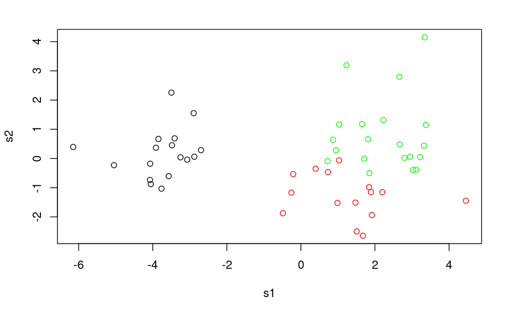

```r
couleur = c(rep('black',17),rep('red',15),rep('green',20))
plot(s1,s2,col=couleur)
```

- Un graphe présente les individus de chaque classe:
  - noire: KIRSCH
  - rouge: MIRAB
  - vert: POIRE

# 5. Prédiction des classes pour l’échantillon test

```r
pred = predict(res, newdata=test)#prédire les classes de chaque individus du dataset test
attributes(pred)
```

```
$names
[1] "class"     "posterior" "x"
```

```r
table(pred$class)#la distribution des prédictions
```

```
KIRSCH  MIRAB  POIRE
    15     19     16
```

- On affiche chaque classes: la classe “KIRSCH”, “MIRAB” et “POIRE” avec le nombre de leurs individus (resp) 15, 19 et 16.

```r
head(pred$posterior)#entre 0 et 1, les probabilités posteriori
```

```
     KIRSCH        MIRAB        POIRE
1 1.0000000 1.535523e-08 4.487814e-10
2 0.9999886 1.109717e-05 3.307808e-07
3 0.9999972 2.730580e-06 2.193638e-08
4 0.9999924 7.523981e-06 5.271811e-08
5 0.9998616 1.116948e-04 2.673034e-05
6 1.0000000 1.745132e-08 1.549001e-10
```

- “pred$posterior” affiche les probabilités posteriori pour chaque individu par rapport à chaque classe.

```r
head(pred$x)#les variables discriminantes(les projections des individus sur les axes discriminants)
```

```
        LD1        LD2
1 -4.416715  0.7309797
2 -3.256389  0.2157101
3 -3.664270 -0.2245967
4 -3.502808 -0.3627711
5 -2.594041  0.9087476
6 -4.540768  0.2192393
```

- pred$x: affiche les variables discriminantes

# 6. Evaluation des résultats obtenus sur l’échantillon test

```r
CM = table(test[,1],pred$class)#confusion matrix
CM
```

```
         KIRSCH MIRAB POIRE
  KIRSCH     14     0     0
  MIRAB       0    14     3
  POIRE       1     5    13
```

- On résume les résultats dans la matrice de confusion pour comparer les données réelles avec nos résultats
  - On remarque que pour la classe “KIRSCH”, il y a 14 individus qui sont justes et 1 seul individu du classe “POIRE” qui est mal classé.
  - Pour la classe “MIRAB”, il y a 14 individus qui sont justes et 5 individus qui sont de la classe “POIRE” sont mal classés.
  - Pour la classe “POIRE”, il y a 13 individus qui sont justes et 3 individus qui sont de la classe “MIRAB” sont mal classés.

```r
accuracy = (sum(diag(CM))/sum(CM))*100
accuracy
```

```
[1] 82
```

- On calcule l’exactitude de notre résultats.
- Nos résultats sont 82% fiables.

```r
error = 100-accuracy
error
```

```
[1] 18
```

- On calcule l’erreur et ça donne 18%

# On applique l’analyse discriminante quadratique

```r
res2 = qda(TYPE~MEOH+ACET+BU1+BU2+ISOP+MEPR+PRO1+ACAL, data = apprentissage)
attributes(res)
```

```
$names
 [1] "prior"   "counts"  "means"   "scaling" "lev"     "svd"     "N"       "call"    "terms"   "xlevels"

$class
[1] "lda"
```

- la fonction “qda” applique l’analyse discriminante quadratique.

```r
pred2 = predict(res2, newdata=test)
```

```r
accuracy2 = (sum(diag(CM2))/sum(CM2))*100#accuracy= la somme du diagonal / le total ( le taux de bon classement)
accuracy2
```

[output not shown]

```
[1] 86
```

- On calcule l’exactitude des résultats .

```r
error2 = 100-accuracy2
error2
```

```
[1] 14
```

- On calcule le pourcentage d’erreur.

# Conclusion

- On compare les résultats de lda et qda:

|  | LDA | QDA |
| --- | --- | --- |
| **Accuracy** | 82 | 86 |
| **Error** | 18 | 14 |

- Les résultats de la méthode “QDA” sont meilleurs que celle de la méthose “LDA”.
- La différence entre les résultats des deux méthodes n’est pas grande.
- L’analyse discriminantes n’est pas 100% exacte.